# Navigation

# Navigation shows you how to get from one place to another

`Navigation` finds a path between two points in 3D space, avoiding any obstacles in its path.

It’s ideal for creating AI that considers its surroundings while hunting for a target. Some examples are enemies chasing the player or army units that avoid hazards as they move into position.

`Navigation` has some shortcomings that Godot 4.0 is due to fix, but it works as a quick and straightforward solution to pathfinding in Godot 3.x.

In this guide, you will learn how to:

- Set up a `Navigation` node.
- Create simple pathfinding.
- Get chased by enemy AI.
- Avoid locked doors.
- Set up grid-based movement.

Contents:

- Setting up Navigation
- Navigation’s key features
  - Find target locations with get_closest_point()
  - Find paths with get_simple_path()
  - Switch between NavigationMeshInstances with Enabled
- How to use Navigation in practice
  - Making enemies chase the player
  - Making areas inaccessible with doors
  - Grid-based navigation
- Your questions
  - When should I use AStar?
  - How can I see my Navigation shapes?
  - Can I create my NavigationMesh in code?
  - Is it possible to use Navigation for flying pathfinding?

## Setting up Navigation

Every `Navigation` node needs to have a child `NavigationMeshInstance` before it can find paths. This child holds a `NavigationMesh` resource, which defines the space available for points and paths.

To generate a `NavigationMesh`, you first need to add a new `NavigationMesh` resource to the `NavigationMeshInstance` and configure which parts of the scene to include in the `Navigation` under the `Geometry` subsection.

You can configure the `NavigationMesh` to generate the mesh based on *Mesh Instances*, *Static Colliders*, or both. With the *Source Geometry Mode* property, you can choose whether the mesh is based on node children of the `NavigationMesh` or nodes with a specific *Group* set.

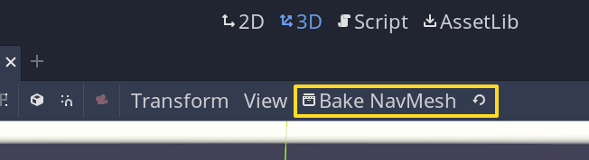

Now, you can use the *Bake NavMesh* button at the top of the viewport and see the generated `NavigationMesh`. You can further fine-tune the baking by adjusting the other parameters in the `NavigationMeshInstance`. You can set the *Max Slope* in the *Agent* sub-category to control how steep the mesh can be before it blocks an agent from traversing it. The *Height* and *Radius* options let you control what the minimum amount of space an agent needs to traverse a part of the level.

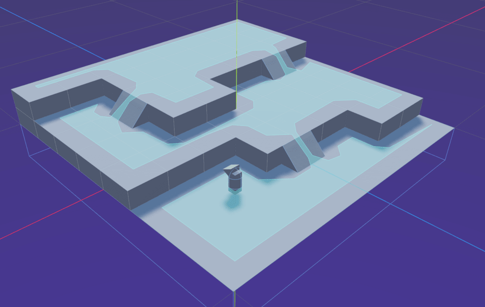

## Navigation’s key features

### Find target locations with get_closest_point()

If you pass a position to this function, it returns the closest valid point on the `NavigationMesh`. This function is essential if you have two navigation meshes and want a body to navigate from one to another, or to ensure your AI won’t go out of bounds.

### Find paths with get_simple_path()

This function is what makes *Navigation* so helpful. You pass in two points as parameters, where you want to navigate to and from on the `NavigationMesh`. The function finds the nearest points on the mesh and returns a `PoolVector3Array` path from the origin to the destination.

The `get_simple_path()` function has three parameters: a start position, an end position, and a *Boolean* called *Optimize*. *Optimize* is an optional parameter that merges points in a straight line, and it’s set to `true` by default.

The `get_simple_path()` function is far from perfect because it can return unoptimized paths. Godot 4.0 looks to fix these imperfections, but it gives decent results with a little tweaking for most situations.

### Switch between NavigationMeshInstances with Enabled

The `NavigationMeshInstance` itself has a few key properties that help customize the area you want to navigate.

You can access and edit the `NavigationMesh` using the *Navmesh* property.

Also, you can enable or disable an entire `NavigationMeshInstance` with the *Enabled* property. A `Navigation` can use only one `NavigationMeshInstance` at a time, so we can change the shape by enabling one mesh and disabling the others.

## How to use Navigation in practice

Now let’s look at some concrete use cases for `Navigation`.

### Making enemies chase the player

Almost all games with enemies have some simple pathfinding behind their movement.

For example, *Hotline Miami* has enemies that rush you with baseball bats, while *Civilization V* has units moving from tile to tile. At its core, almost any game needs some simple form of pathfinding to avoid characters crashing into walls.

`Navigation` is the ideal node for this behavior in Godot. In the example below, we have an enemy character that chases the player.

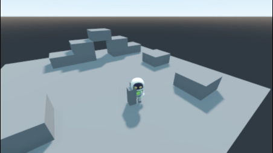

We use a `GridMap` to make the floor and obstacles and bake a `NavigationMesh` to calculate the navigation space.

Our scene tree ends looking like this. Note that the `GridMap` is a child of `NavigationMeshInstance`, since we use the default configuration, where the children of the `NavigationMeshInstance` are used for baking the `NavigationMesh`.

[figure not shown]

Our navigation enemy uses a typical `KinematicBody` setup.

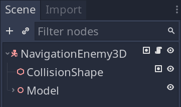

Our enemy needs a reference to the `Navigation` node and the target it’s following: in this case, our player.

```
onready var _model: Spatial = $Model
onready var _navigation: Navigation = get_node(navigation_path) as Navigation
onready var _player: Player3D = get_node(player_path) as Player3D
```

The algorithm for the navigation path is performance-intensive, so we use a frame counter variable to only look for a new path every tenth frame.

```
const FRAMES_BETWEEN_UPDATES := 10

func _physics_process(delta: float) -> void:
    if _frame_counter == 0:
        # We attempt to get a path from the enemy to the player.
        var potential_path = _navigation.get_simple_path(
            global_transform.origin, _player.global_transform.origin
        )
        # If the path array we get back is larger than 0 it's a valid path
        # and we assign it otherwise we stick to the old path.
        if potential_path.size() > 0:
            _path = potential_path
    _frame_counter = wrapi(_frame_counter + 1, 0, FRAMES_BETWEEN_UPDATES)
```

We now have a valid path to the player, but we need to remove points as the enemy arrives at them as we follow it.

```
    var position_on_navigation_mesh = _navigation.get_closest_point(global_transform.origin)

    # When we get close to the next point on the path, we remove that point
    if (
        position_on_navigation_mesh.distance_squared_to(_path[0]) < path_tolerance
        and _path.size() > 1
    ):
        _path.remove(0)
```

We find the direction to the next point and normalize it. We can then use it to orient the character model towards that direction. The `_orient_character_to_direction()` function calculates the rotation basis for the direction and uses the `slerp()` function to smoothly rotate the character towards this direction.

```
    var direction: Vector3 = _path[0] - position_on_navigation_mesh

    direction.y = 0.0
    direction = direction.normalized()

    _orient_character_to_direction(direction, delta)

func _orient_character_to_direction(direction: Vector3, delta: float) -> void:
    var left_axis := Vector3.UP.cross(direction)
    var rotation_basis := Basis(left_axis, Vector3.UP, direction)
    _model.transform.basis = _model.transform.basis.slerp(rotation_basis, delta * rotation_speed)
```

The final destination is the last point of the path. We use this to check if we have arrived at the endpoint. If we haven’t arrived yet, we calculate a velocity with `linear_interpolate()` and apply it to the `KinematicBody` with the `move_and_slide_with_snap()` function.

```
    var final_destination := _path[_path.size() - 1]

    if position_on_navigation_mesh.distance_squared_to(final_destination) > stopping_distance:
        _velocity = _velocity.linear_interpolate(direction * move_speed, acceleration * delta)
        _velocity = move_and_slide_with_snap(_velocity, _snap, Vector3.UP, true)
```

**Note:** The `Path` and `PathFollow` nodes pair excellently with the paths generated by a `Navigation` node. If you don’t want to move your characters towards points on a path manually, you can use these nodes instead, as laid out in the Path guide.

### Making areas inaccessible with doors

It’s rare to have explorable worlds that don’t have some form of gate or door. In games like *Resident Evil*, different areas become available as you progress through the game, but certain enemies need to be able to follow you through doors once they’re unlocked.

One way to get enemies to respond to unlocked doors is to use a `Navigation` node with multiple `NavigationMeshInstance` children. You can switch between them using the *Enabled* property.

This method works well in simpler situations because the number of `NavigationMeshInstance` nodes increases exponentially with every locked door. With this approach, you also need code to handle the *Enabled* property for each `NavigationMeshInstance`.

For our example, we made two doors and one switch. The switch opens one door and closes the other. As a result, we only have two states to swap between, so we need two `NavigationMeshInstance` nodes.

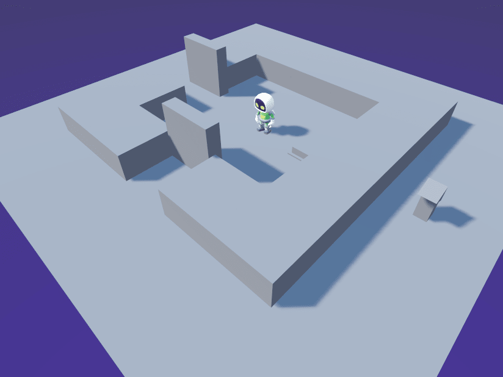

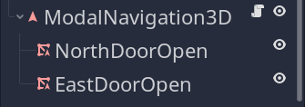

You can read more about the door and pressure plate mechanisms in the Area guide.

Here we use a `Dictionary`, so the script can enable its matching `NavigationMeshInstance` when one door opens and disable the rest.

```
export var north_door_path: NodePath
export var east_door_path: NodePath

onready var _north_door = get_node(north_door_path)
onready var _east_door = get_node(east_door_path)
onready var _door_map := {
    _north_door: $NorthDoorOpen,
    _east_door: $EastDoorOpen,
}


func _ready() -> void:
    _door_map[_east_door].enabled = true


func activate() -> void:
    for door in _door_map:
        door.activate()
        _door_map[door].enabled = !_door_map[door].enabled
```

When our `NavigationMeshInstance` updates, the `Navigation` node uses whatever mesh is enabled when generating paths.

### Grid-based navigation

Many games have pathfinding with restricted areas units can stand on, such as turn-based tactics games like *XCOM*.

If you want to restrict your movement to start and end on a grid, but you don’t mind if the movement isn’t locked to the grid, then `Navigation` is an excellent option.

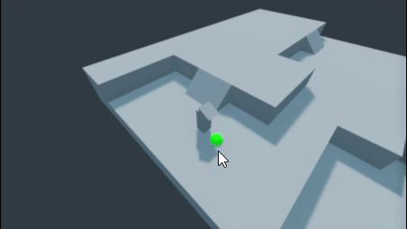

The principle of using a `Navigation` for grid-based movement is the same as with enemy AI in the first example. Still, you need some extra steps to get the target position from a mouse click in 3D space and ensure the position is on the nearest valid grid position.

To get the position in 3D space from our mouse click, we project a ray from the camera position.

Now we have the world position from the raycast; we can pass it through the `get_closest_point()` function to get a position on the navigation mesh.

Finally, we set the position of a grid cursor, which is a spherical `MeshInstance`. The `Vector3` `snapped()` function ensures the positions are always on our grid.

```
    if event is InputEventMouseMotion:
        var from := _camera.project_ray_origin(event.position)
        var to := from + _camera.project_ray_normal(event.position) * 9999.0
        var space := get_world().direct_space_state
        var result := space.intersect_ray(from, to)
        if result:
            var point = _navigation.get_closest_point(result["position"])
            # We need to negatively offset the point we get on the navigation
            # mesh by 2 x the height set on the Navigation Mesh Instance on the
            # y-axis for it to align exactly with the mesh.
            point -= Vector3(0.0, _navigation_mesh_instance.navmesh.get("cell/height") * 2.0, 0.0)
            _set_grid_cursor(point)
func _set_grid_cursor(position: Vector3) -> void:
    position = position.snapped(Vector3(1.0, 1.0, 1.0))
    _cursor.global_transform.origin = position
```

We listen for the user clicking and set the player destination to the cursor position.

```
    if event.is_action_pressed("shoot_3d"):
        _player.set_destination(_cursor.global_transform.origin)
```

The `set_destination()` function gets called in the player script, which starts the player processing.

```
func set_destination(position: Vector3):
    _path = _navigation.get_simple_path(global_transform.origin, position)
    set_physics_process(true)
```

```
func _physics_process(delta: float) -> void:
    var position_on_navigation_mesh = _navigation.get_closest_point(global_transform.origin)
    var final_destination := _path[_path.size() - 1]

    if (
        position_on_navigation_mesh.distance_squared_to(_path[0]) < path_tolerance
        and _path.size() > 1
    ):
        _path.remove(0)

    var direction: Vector3 = _path[0] - position_on_navigation_mesh

    direction.y = 0.0
    direction = direction.normalized()
    _orient_character_to_direction(direction, delta)

    _velocity = _velocity.linear_interpolate(direction * move_speed, acceleration * delta)
    _velocity = move_and_slide_with_snap(_velocity, _snap, Vector3.UP, true, 4, deg2rad(60))
```

## Your questions

### When should I use AStar?

You can get more robust results and control using the `AStar` algorithm with more manual work. If you’re struggling with the unpredictable and imprecise nature of `Navigation` in Godot 3.x, it’s worth considering implementing the pathfinding yourself using `AStar`. You can read the [Godot Docs on AStar here.](https://docs.godotengine.org/en/stable/classes/class_astar.html)

### How can I see my Navigation shapes?

Godot has a handy option in the debug dropdown. The *Visible Navigation* checkmark makes all *NavigationMeshes* visible in-game when enabled.

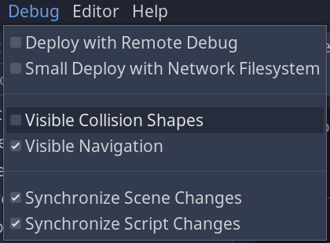

### Can I create my NavigationMesh in code?

Yes. To create a `NavigationMesh` from code, you need to call `set_vertices()` and `add_polygon()` or `create_from_mesh()` and manually add the `NavigationMesh` with the `navmesh_add()` function. Note that when doing this, you don’t need a `NavigationMeshInstance` node.

Here is a simple example of adding a single three-sided polygon as a `NavigationMesh`.

```
extends Navigation


func _ready() -> void:
    var nav_mesh := NavigationMesh.new()
    var vertices := PoolVector3Array([Vector3(-1.0, 0.5, 1.0), Vector3(1.0, 0.5, 1.0), Vector3(0.0, 0.5, -1.0)])
    var polygon := PoolIntArray([0, 1, 2])
    nav_mesh.set_vertices(vertices)
    nav_mesh.add_polygon(polygon)
    navmesh_add(nav_mesh, Transform.IDENTITY)
```

### Is it possible to use Navigation for flying pathfinding?

No. The navigation paths you get back from the `Navigation` system are based on mesh shapes and thus only know how to get from one point on a mesh to another point on the mesh.